# Bayesian Detection of Differential Item Functioning Under the Rasch Model

Monika Bagociute

September 18, 2026

## Research overview

This project investigates the detection of Differential Item Functioning (DIF) under the Rasch model using Bayesian estimation.

The analysis has two components. First, a simulation study evaluates whether a custom Metropolis–Hastings sampler can recover known DIF parameters and compares its estimates with those obtained from JAGS. Second, the Bayesian approach is applied to an empirical assessment dataset and compared with the classical Mantel–Haenszel procedure.

### Research question

Can Bayesian estimation reliably detect DIF under the Rasch model, and how do the results compare with a classical DIF detection procedure?

### Analytical workflow

The analysis demonstrates:

- Simulation-based validation of a statistical estimation procedure
- Bayesian parameter estimation using Metropolis–Hastings MCMC
- Validation against JAGS
- Posterior means and credible intervals
- MCMC diagnostics, including trace and autocorrelation plots
- Empirical DIF analysis
- Comparison of Bayesian and Mantel–Haenszel results
- Bayesian hypothesis testing

### Tools

- R
- R Markdown
- JAGS
- Metropolis–Hastings MCMC
- Bayesian estimation
- Rasch modelling
- DIF analysis

#### Simulation

Data were simulated under a Rasch model. The dataset consisted of 500 participants responding to 10 dichotomous items. Participants were randomly assigned to one of two groups, which may be interpreted, for example, as boys and girls. Differential Item Functioning (DIF) was introduced for Items 3 and 8 by allowing group membership to affect the probability of a correct response, whereas the remaining items were assumed to function equivalently across groups.

```r
library(rjags)
library(coda)
#library(difR)
library(bain)
library(restriktor)
library(knitr)
library(xtable)

set.seed(123456)

# persons
N <- 500
# items
J <- 10

# assign them randomly to a group
group <- rbinom(n = N, size = 1, prob = .50)
table(group)
```

```
## group
##   0   1
## 254 246
```

```r
# draw the ability estimates from the normal distrib,
theta <- rnorm(n = N, mean = 0, sd = 1)
#theta
# draw the difficulty parameters from the normal distrib.
b <- rnorm(n = J, mean = 0, sd = 1)
#b

# Introducing DIF
delta <- rep(0, J)

# item 3 harder
delta[3] <- 1

# Item 8 easier
delta[8] <- -1

#delta
```

We continue generating the responses.

```r
# response matrix (empti)
Y <- matrix(0, nrow = N, ncol = J)
#Y

# generating responses
for(i in 1:N){
for(j in 1:J){
eta <-theta[i] -b[j] - delta[j] * group[i]
p <- plogis(eta) # rasch function
Y[i,j] <- rbinom(n = 1, size = 1, prob = p)
  }
}

# check up
dim(Y) # correct dim
```

```
## [1] 500  10
```

```r
round(colMeans(Y), 3) # we see the % of responding correctly
```

```
##  [1] 0.910 0.736 0.576 0.502 0.798 0.318 0.398 0.374 0.078 0.338
```

```r
rbind(
  Reference = colMeans(Y[group == 0, ]),
  Focal = colMeans(Y[group == 1, ])
) # for item 3 and item 8 we see a clear difference
```

```
##                [,1]      [,2]      [,3]      [,4]      [,5]      [,6]      [,7]
## Reference 0.9094488 0.7165354 0.6614173 0.4842520 0.7677165 0.3149606 0.4094488
## Focal     0.9105691 0.7560976 0.4878049 0.5203252 0.8292683 0.3211382 0.3861789
##                [,8]       [,9]     [,10]
## Reference 0.2322835 0.08661417 0.3425197
## Focal     0.5203252 0.06910569 0.3333333
```

The simulated data seems correct.

```r
# storing
simdata <- list(Y = Y, theta_true = theta, b_true = b, delta_true = delta,
  group = group
)

saveRDS(
  simdata,
  "../Data/processed/simulated_rasch_dif.rds"
)
```

Theoretical curves using the generating mechanism. I am using this information for my final report only.

```r
pdf("../Figures/theoretical_item_response_curves.pdf",
    width = 12,
    height = 7)

par(mfrow = c(2, 5))

theta_grid <- seq(-3, 3, length.out = 200)

for (j in 1:J) {

  p_ref <- plogis(theta_grid - b[j])

  p_focal <- plogis(
    theta_grid - b[j] - delta[j]
  )

  plot(
    theta_grid,
    p_ref,
    type = "l",
    ylim = c(0, 1),
    main = paste("Item", j),
    xlab = "Theta",
    ylab = "P"
  )

  lines(
    theta_grid,
    p_focal,
    lty = 2
  )
}

dev.off()
```

#### JAGS

Since the true values of the item and DIF parameters are known in the simulated data, agreement between the estimates obtained from the JAGS and Metropolis-Hastings sampler provides evidence that the implemented algorithm correctly approximates the posterior distributions.

```r
model_string <- "
model{

for(i in 1:N){

for(j in 1:J){

Y[i,j] ~ dbern(p[i,j])

logit(p[i,j]) <- theta[i] - b[j] - delta[j]*group[i]} }

  # Priors

for(j in 1:J){

b[j] ~ dnorm(0,1)

delta[j] ~ dnorm(0,1)}}
"
```

Data for JAGS

```r
library(rjags)

jags_data <- list(
Y = Y,
N = N,
J = J,
group = group,
theta = theta

)
```

Initial values

```r
inits <- function(){
list(b = rnorm(J,0,1), delta = rep(0,J))
}
```

Fitting the model

```r
mod <- jags.model(
  textConnection(model_string),
  data = jags_data,
  inits = inits,
  n.chains = 3,
  n.adapt = 2000
)
```

```r
# burn-in
update(mod, 5000) # takes some time

# draw posterior samples

library(coda)

samples <- coda.samples(model = mod, variable.names = c("b","delta"), n.iter = 10000)
```

Extract JAGS estimates

```r
summary(samples)
```

```
##
## Iterations = 7001:17000
## Thinning interval = 1
## Number of chains = 3
## Sample size per chain = 10000
##
## 1. Empirical mean and standard deviation for each variable,
##    plus standard error of the mean:
##
##                Mean     SD  Naive SE Time-series SE
## b[1]      -2.595236 0.2110 0.0012183       0.002448
## b[2]      -1.114466 0.1486 0.0008579       0.001859
## b[3]      -0.791180 0.1427 0.0008236       0.001813
## b[4]       0.055242 0.1352 0.0007807       0.001643
## b[5]      -1.425312 0.1562 0.0009016       0.001806
## b[6]       0.891257 0.1423 0.0008217       0.001726
## b[7]       0.418391 0.1388 0.0008015       0.001679
## b[8]       1.333727 0.1538 0.0008880       0.002046
## b[9]       2.591956 0.2163 0.0012491       0.002404
## b[10]      0.754031 0.1415 0.0008171       0.001721
## delta[1]  -0.003493 0.3054 0.0017634       0.003544
## delta[2]  -0.123279 0.2152 0.0012427       0.002631
## delta[3]   0.947445 0.1986 0.0011466       0.002498
## delta[4]  -0.037162 0.1919 0.0011077       0.002305
## delta[5]  -0.327723 0.2320 0.0013397       0.002700
## delta[6]   0.128147 0.2015 0.0011634       0.002400
## delta[7]   0.253971 0.1973 0.0011389       0.002421
## delta[8]  -1.289382 0.2052 0.0011845       0.002712
## delta[9]   0.520812 0.3243 0.0018722       0.003619
## delta[10]  0.193785 0.2018 0.0011651       0.002375
##
## 2. Quantiles for each variable:
##
##              2.5%       25%       50%      75%   97.5%
## b[1]      -3.0207 -2.735746 -2.590298 -2.45092 -2.1890
## b[2]      -1.4112 -1.213458 -1.112927 -1.01297 -0.8246
## b[3]      -1.0711 -0.887570 -0.789688 -0.69461 -0.5154
## b[4]      -0.2096 -0.036846  0.055499  0.14783  0.3186
## b[5]      -1.7340 -1.530569 -1.424113 -1.31894 -1.1223
## b[6]       0.6131  0.795221  0.891157  0.98671  1.1741
## b[7]       0.1486  0.324707  0.417214  0.51157  0.6935
## b[8]       1.0376  1.228553  1.332137  1.43685  1.6377
## b[9]       2.1832  2.442709  2.586523  2.73536  3.0289
## b[10]      0.4762  0.658081  0.755003  0.84954  1.0297
## delta[1]  -0.6065 -0.208957 -0.002881  0.20195  0.5932
## delta[2]  -0.5491 -0.268385 -0.122029  0.02321  0.2941
## delta[3]   0.5581  0.815500  0.947606  1.08133  1.3348
## delta[4]  -0.4090 -0.167846 -0.037673  0.09323  0.3383
## delta[5]  -0.7838 -0.483730 -0.325292 -0.17019  0.1266
## delta[6]  -0.2669 -0.007122  0.127274  0.26376  0.5237
## delta[7]  -0.1372  0.120815  0.255771  0.38826  0.6330
## delta[8]  -1.6914 -1.426740 -1.287571 -1.15076 -0.8904
## delta[9]  -0.1112  0.301846  0.517776  0.73599  1.1624
## delta[10] -0.1961  0.057044  0.191670  0.32940  0.5932
```

```r
stats <- summary(samples)$statistics
delta_rows <- grep("^delta", rownames(stats))
delta_est <- stats[delta_rows,"Mean"]
delta_est
```

```
##     delta[1]     delta[2]     delta[3]     delta[4]     delta[5]     delta[6]
## -0.003493348 -0.123279461  0.947445320 -0.037162177 -0.327723449  0.128147263
##     delta[7]     delta[8]     delta[9]    delta[10]
##  0.253970538 -1.289382201  0.520811981  0.193785441
```

#### MH sampler

```r
set.seed(123)


n_iter <- 10000
burnin <- 2000


prop_b <- 0.3
prop_delta <- 0.3


# Initial values
b_mh <- rep(0, J)
delta_mh <- rep(0, J)


# Storage

b_store <- matrix(NA, n_iter, J)
delta_store <- matrix(NA, n_iter, J)

# vectors count how many proposals are accepted for each item
acc_b <- rep(0, J)
acc_delta <- rep(0, J)
```

Log likelihood for a single item

```r
loglik_item <- function(b, delta, y, theta, group){
eta <- theta - b - delta*group
p <- plogis(eta)
sum(y*log(p) + (1-y)*log(1-p)) # we turned products into sums, computationally easier
}
```

Prior

```r
logprior <- function(x){dnorm(x, mean = 0, sd = 1, log = TRUE)
}
```

```r
for(iter in 1:n_iter){

# update b
  for(j in 1:J){
 # Propose new difficulty
b_prop <- rnorm(1, mean = b_mh[j],sd = prop_b)
# Current log-posterior
logpost_current <-loglik_item( b = b_mh[j],delta = delta_mh[j],y = Y[,j],theta = theta,group = group) +logprior(b_mh[j])
# Proposed log-posterior
logpost_prop <-loglik_item(b = b_prop, delta = delta_mh[j],y = Y[,j],theta = theta,group = group) +logprior(b_prop)
# Log acceptance ratio
log_alpha <-logpost_prop -logpost_current
# Accept or reject
if(log(runif(1)) < log_alpha){
b_mh[j] <- b_prop
acc_b[j] <- acc_b[j] + 1
}

  }

  # update DIF param.


  for(j in 1:J){
# Propose new DIF parameter
delta_prop <- rnorm(1, mean = delta_mh[j],sd = prop_delta)
# Current log-posterior
logpost_current <-loglik_item(b = b_mh[j],delta = delta_mh[j],y = Y[,j],theta = theta,group = group) +
      logprior(delta_mh[j])

# Proposed log-posterior
logpost_prop <-loglik_item(b = b_mh[j],delta = delta_prop,y = Y[,j],theta = theta,group = group) +logprior(delta_prop)

# Log acceptance ratio
log_alpha <-logpost_prop -logpost_current
# Accept or reject
if(log(runif(1)) < log_alpha){

delta_mh[j] <- delta_prop

acc_delta[j] <- acc_delta[j] + 1

    }

  }

  # store samples


  b_store[iter, ] <- b_mh

  delta_store[iter, ] <- delta_mh

}
```

Acceptance Rates

```r
acc_rate_b <- acc_b / n_iter
acc_rate_delta <- acc_delta / n_iter

acc_rate_b
```

```
##  [1] 0.5157 0.3971 0.3734 0.3698 0.4224 0.3778 0.3636 0.3904 0.5257 0.3857
```

```r
acc_rate_delta
```

```
##  [1] 0.6276 0.5221 0.4777 0.4746 0.5473 0.4969 0.4790 0.4823 0.6555 0.4879
```

Posterior Summaries

```r
delta_post <- delta_store[ (burnin + 1):n_iter,]


delta_mean <- apply(
  delta_post,
  2,
  mean
)
```

CI

```r
delta_ci <- apply(
  delta_post,
  2,
  quantile,
  probs = c(0.025, 0.975)
)
```

Results

```r
results <- data.frame(

  Item = 1:J,

  True_DIF = delta,

  Posterior_Mean = round(
    delta_mean,
    3
  ),

  Lower95 = round(
    delta_ci[1,],
    3
  ),

  Upper95 = round(
    delta_ci[2,],
    3
  )

)

results
```

```
##    Item True_DIF Posterior_Mean Lower95 Upper95
## 1     1        0          0.008  -0.605   0.618
## 2     2        0         -0.135  -0.537   0.291
## 3     3        1          0.952   0.563   1.324
## 4     4        0         -0.036  -0.410   0.343
## 5     5        0         -0.326  -0.762   0.134
## 6     6        0          0.133  -0.266   0.537
## 7     7        0          0.264  -0.117   0.655
## 8     8       -1         -1.296  -1.694  -0.882
## 9     9        0          0.501  -0.108   1.113
## 10   10        0          0.221  -0.153   0.602
```

Trace plots

```r
pdf(
  "../Figures/mh_trace_plots.pdf",
  width = 9,
  height = 7
)

par(mfrow = c(2, 2))

plot(
  delta_store[, 3],
  type = "l",
  main = expression(delta[3]),
  xlab = "Iteration",
  ylab = "DIF parameter"
)

plot(
  delta_store[, 8],
  type = "l",
  main = expression(delta[8]),
  xlab = "Iteration",
  ylab = "DIF parameter"
)

plot(
  delta_store[, 1],
  type = "l",
  main = expression(delta[1]),
  xlab = "Iteration",
  ylab = "DIF parameter"
)

plot(
  delta_store[, 2],
  type = "l",
  main = expression(delta[2]),
  xlab = "Iteration",
  ylab = "DIF parameter"
)

dev.off()
```

Some tables for the results

```r
# JAGS estimates of delta

stats <- summary(samples)$statistics

delta_rows <- grep("^delta", rownames(stats))

delta_est <- stats[delta_rows, "Mean"]

delta_est
```

```
##     delta[1]     delta[2]     delta[3]     delta[4]     delta[5]     delta[6]
## -0.003493348 -0.123279461  0.947445320 -0.037162177 -0.327723449  0.128147263
##     delta[7]     delta[8]     delta[9]    delta[10]
##  0.253970538 -1.289382201  0.520811981  0.193785441
```

table

```r
comparison_table <- data.frame(

  Item = 1:J,

  True_DIF = delta,

  MH = round(delta_mean, 3),

  JAGS = round(delta_est, 3)

)

comparison_table
```

```
##           Item True_DIF     MH   JAGS
## delta[1]     1        0  0.008 -0.003
## delta[2]     2        0 -0.135 -0.123
## delta[3]     3        1  0.952  0.947
## delta[4]     4        0 -0.036 -0.037
## delta[5]     5        0 -0.326 -0.328
## delta[6]     6        0  0.133  0.128
## delta[7]     7        0  0.264  0.254
## delta[8]     8       -1 -1.296 -1.289
## delta[9]     9        0  0.501  0.521
## delta[10]   10        0  0.221  0.194
```

plot

```r
pdf(
  "../Figures/mh_vs_jags_estimates.pdf",
  width = 7,
  height = 6
)

plot(
  delta_est,
  delta_mean,
  pch = 19,
  xlab = "JAGS estimate",
  ylab = "MH estimate",
  main = "Metropolis–Hastings versus JAGS"
)

abline(
  a = 0,
  b = 1,
  lty = 2
)

text(
  delta_est,
  delta_mean,
  labels = 1:J,
  pos = 3
)

dev.off()
```

Acceptance rate

```r
acceptance_table <- data.frame(

  Item = 1:J,

  Difficulty = round(acc_rate_b,3),

  DIF = round(acc_rate_delta,3)

)

library(knitr)

kable(
  acceptance_table,
  caption = "Acceptance rates of the Metropolis--Hastings algorithm."
)
```

Acceptance rates of the Metropolis–Hastings algorithm.

| Item | Difficulty | DIF |
| --- | --- | --- |
| 1 | 0.516 | 0.628 |
| 2 | 0.397 | 0.522 |
| 3 | 0.373 | 0.478 |
| 4 | 0.370 | 0.475 |
| 5 | 0.422 | 0.547 |
| 6 | 0.378 | 0.497 |
| 7 | 0.364 | 0.479 |
| 8 | 0.390 | 0.482 |
| 9 | 0.526 | 0.655 |
| 10 | 0.386 | 0.488 |

autocorrelation plots

```r
pdf(
  "../Figures/mh_autocorrelation_plots.pdf",
  width = 9,
  height = 5
)

par(mfrow = c(1, 2))

acf(
  delta_post[, 3],
  main = expression(delta[3]),
  xlab = "Lag"
)

acf(
  delta_post[, 8],
  main = expression(delta[8]),
  xlab = "Lag"
)

dev.off()
```

acceptance ratio

```r
acceptance_table <- data.frame(

  Item = 1:J,

  Difficulty = round(acc_rate_b,3),

  DIF = round(acc_rate_delta,3)

)

acceptance_table
```

```
##    Item Difficulty   DIF
## 1     1      0.516 0.628
## 2     2      0.397 0.522
## 3     3      0.373 0.478
## 4     4      0.370 0.475
## 5     5      0.422 0.547
## 6     6      0.378 0.497
## 7     7      0.364 0.479
## 8     8      0.390 0.482
## 9     9      0.526 0.655
## 10   10      0.386 0.488
```

Comparing with JAGS

```r
comparison_table <- data.frame(

  Item = 1:J,

  True_DIF = delta,

  MH = round(delta_mean,3),

  JAGS = round(delta_est,3)

)

comparison_table
```

```
##           Item True_DIF     MH   JAGS
## delta[1]     1        0  0.008 -0.003
## delta[2]     2        0 -0.135 -0.123
## delta[3]     3        1  0.952  0.947
## delta[4]     4        0 -0.036 -0.037
## delta[5]     5        0 -0.326 -0.328
## delta[6]     6        0  0.133  0.128
## delta[7]     7        0  0.264  0.254
## delta[8]     8       -1 -1.296 -1.289
## delta[9]     9        0  0.501  0.521
## delta[10]   10        0  0.221  0.194
```

### Practical usefulness

the method is validated, now is the time to apply it

#### Empirical data

```r
library(difR)

data(package = "difR")
```

```r
data(verbal)
```

```r
str(verbal)
```

```
## 'data.frame':    316 obs. of  26 variables:
##  $ S1wantCurse: int  0 0 1 1 1 1 1 0 0 1 ...
##  $ S1WantScold: int  0 0 1 1 0 1 1 0 0 1 ...
##  $ S1WantShout: int  0 0 1 1 1 0 1 0 0 1 ...
##  $ S2WantCurse: int  0 0 1 1 1 1 1 0 1 1 ...
##  $ S2WantScold: int  0 0 0 1 0 0 1 0 1 1 ...
##  $ S2WantShout: int  0 0 1 1 0 0 1 0 0 1 ...
##  $ S3WantCurse: int  0 0 1 1 1 1 1 0 1 1 ...
##  $ S3WantScold: int  0 0 0 0 0 1 0 0 0 0 ...
##  $ S3WantShout: int  1 0 0 0 0 1 1 0 1 1 ...
##  $ S4WantCurse: int  1 0 0 0 1 0 0 0 1 1 ...
##  $ S4WantScold: int  0 0 0 0 0 0 0 0 0 1 ...
##  $ S4WantShout: int  0 0 0 0 0 0 0 0 0 1 ...
##  $ S1DoCurse  : int  1 0 0 1 1 1 1 1 1 1 ...
##  $ S1DoScold  : int  0 0 1 1 1 0 1 0 0 1 ...
##  $ S1DoShout  : int  1 0 1 1 0 0 1 0 0 1 ...
##  $ S2DoCurse  : int  1 0 0 1 1 1 1 1 1 1 ...
##  $ S2DoScold  : int  0 0 0 1 0 0 1 0 0 1 ...
##  $ S2DoShout  : int  0 0 1 1 0 0 1 0 0 1 ...
##  $ S3DoCurse  : int  1 1 0 1 1 1 0 1 1 0 ...
##  $ S3DoScold  : int  0 0 0 0 0 0 0 0 0 0 ...
##  $ S3DoShout  : int  0 0 0 0 0 0 0 0 1 0 ...
##  $ S4DoCurse  : int  1 0 1 0 1 1 0 1 0 1 ...
##  $ S4DoScold  : int  1 0 0 0 0 1 0 0 1 1 ...
##  $ S4DoShout  : int  1 0 0 0 0 0 0 0 0 1 ...
##  $ Anger      : int  20 11 17 21 17 21 39 21 24 16 ...
##  $ Gender     : int  1 1 0 0 0 0 0 0 0 0 ...
```

```r
names(verbal)
```

```
##  [1] "S1wantCurse" "S1WantScold" "S1WantShout" "S2WantCurse" "S2WantScold"
##  [6] "S2WantShout" "S3WantCurse" "S3WantScold" "S3WantShout" "S4WantCurse"
## [11] "S4WantScold" "S4WantShout" "S1DoCurse"   "S1DoScold"   "S1DoShout"
## [16] "S2DoCurse"   "S2DoScold"   "S2DoShout"   "S3DoCurse"   "S3DoScold"
## [21] "S3DoShout"   "S4DoCurse"   "S4DoScold"   "S4DoShout"   "Anger"
## [26] "Gender"
```

response matrix

```r
Y_verbal <- as.matrix(verbal[,1:24])

dim(Y_verbal)
```

```
## [1] 316  24
```

Group variable

```r
table(verbal$Gender)
```

```
##
##   0   1
## 243  73
```

```r
group_verbal <- verbal$Gender
```

```r
round(colMeans(Y_verbal),3)
```

```
## S1wantCurse S1WantScold S1WantShout S2WantCurse S2WantScold S2WantShout
##       0.712       0.601       0.513       0.788       0.627       0.500
## S3WantCurse S3WantScold S3WantShout S4WantCurse S4WantScold S4WantShout
##       0.595       0.373       0.241       0.690       0.434       0.313
##   S1DoCurse   S1DoScold   S1DoShout   S2DoCurse   S2DoScold   S2DoShout
##       0.712       0.570       0.342       0.655       0.487       0.247
##   S3DoCurse   S3DoScold   S3DoShout   S4DoCurse   S4DoScold   S4DoShout
##       0.459       0.244       0.092       0.627       0.427       0.180
```

Classical DIF

```r
library(difR)

mh_verbal <- difMH(
  Data = Y_verbal,
  group = group_verbal,
  focal.name = 1
)

mh_verbal$DIFitems
```

```
## [1]  6 12 16 17 19 20
```

```r
mh_table <- data.frame(
  Item = 1:24,
  p_value = round(mh_verbal$p.value,4),
  alphaMH = round(mh_verbal$alphaMH,3)
)

mh_table
```

```
##    Item p_value alphaMH
## 1     1  0.1913   1.700
## 2     2  0.1427   1.770
## 3     3  0.3191   1.448
## 4     4  0.1647   1.939
## 5     5  0.0857   1.980
## 6     6  0.0019   2.880
## 7     7  0.9711   0.944
## 8     8  0.4112   0.719
## 9     9  0.3656   1.528
## 10   10  0.2018   1.685
## 11   11  0.9020   1.090
## 12   12  0.0424   2.346
## 13   13  0.7160   0.797
## 14   14  0.0972   0.499
## 15   15  0.7938   1.177
## 16   16  0.0121   0.321
## 17   17  0.0089   0.375
## 18   18  0.6414   0.793
## 19   19  0.0162   0.462
## 20   20  0.0486   0.473
## 21   21  0.5846   0.637
## 22   22  0.2895   0.644
## 23   23  0.2287   0.639
## 24   24  0.3597   1.605
```

Ability estimates (proxy)

```r
theta_verbal <- scale(rowSums(Y_verbal))
```

MH sampler Follow the same as before, the main thing I did now is that I have adjusted J into J_verbal

```r
set.seed(123)

n_iter <- 10000
burnin <- 2000

prop_b <- 0.3
prop_delta <- 0.3

N_verbal <- nrow(Y_verbal)
J_verbal <- ncol(Y_verbal)
```

```r
b_mh <- rep(0, J_verbal)
delta_mh <- rep(0, J_verbal)
```

```r
b_store <- matrix(NA, n_iter, J_verbal)
delta_store <- matrix(NA, n_iter, J_verbal)

acc_b <- rep(0, J_verbal)
acc_delta <- rep(0, J_verbal)
```

Log likelihood

```r
loglik_item <- function(b, delta, y, theta, group){

  eta <- theta - b - delta*group

  p <- plogis(eta)

  sum(y*log(p) +(1-y)*log(1-p))

}
```

Prior Distribution

```r
logprior <- function(x){

  dnorm(
    x,
    mean = 0,
    sd = 1,
    log = TRUE
  )

}
```

Metropolis-Hastings

```r
for(iter in 1:n_iter){
  for(j in 1:J_verbal){

    b_prop <- rnorm(1, mean = b_mh[j], sd = prop_b)
logpost_current <-loglik_item(b_mh[j],delta_mh[j],Y_verbal[,j],theta_verbal,
        group_verbal) +
      logprior(b_mh[j])

    logpost_prop <-
      loglik_item(b_prop,delta_mh[j],Y_verbal[,j],theta_verbal,group_verbal
      ) +
      logprior(b_prop)

    if(
      log(runif(1)) <
      (logpost_prop - logpost_current)
    ){

      b_mh[j] <- b_prop

      acc_b[j] <- acc_b[j] + 1

    }

  }


  # for DIF

  for(j in 1:J_verbal){

    delta_prop <- rnorm(1,mean = delta_mh[j],sd = prop_delta)

    logpost_current <-loglik_item(b_mh[j],delta_mh[j],Y_verbal[,j],theta_verbal,group_verbal
      ) +
      logprior(
        delta_mh[j]
      )

    logpost_prop <-
      loglik_item(
        b_mh[j],
        delta_prop,
        Y_verbal[,j],
        theta_verbal,
        group_verbal
      ) +
      logprior(
        delta_prop
      )

    if(
      log(runif(1)) <
      (logpost_prop - logpost_current)
    ){

      delta_mh[j] <- delta_prop

      acc_delta[j] <- acc_delta[j] + 1

    }

  }



  b_store[iter,] <- b_mh

  delta_store[iter,] <- delta_mh

}
```

Acceptance rate

```r
acc_rate_b <- acc_b / n_iter
acc_rate_delta <- acc_delta / n_iter

acc_rate_b
```

```
##  [1] 0.4549 0.4452 0.4388 0.4865 0.4510 0.4363 0.4427 0.4534 0.4798 0.4577
## [11] 0.4332 0.4574 0.4649 0.4495 0.4475 0.4526 0.4425 0.4726 0.4461 0.4847
## [21] 0.5855 0.4472 0.4469 0.5071
```

```r
acc_rate_delta
```

```
##  [1] 0.6754 0.6524 0.6488 0.7008 0.6643 0.6597 0.6610 0.6565 0.6994 0.6627
## [11] 0.6535 0.6874 0.6840 0.6753 0.6651 0.7017 0.6652 0.6759 0.6620 0.6658
## [21] 0.7412 0.6951 0.6515 0.7252
```

Posterior summaries

```r
delta_post <- delta_store[
  (burnin+1):n_iter,
]
```

Posterior mean

```r
delta_mean <- apply(
  delta_post,
  2,
  mean
)
```

CI

```r
delta_ci <- apply(
  delta_post,
  2,
  quantile,
  probs = c(0.025, 0.975)
)

dim(delta_ci)
```

```
## [1]  2 24
```

Results table

```r
results_verbal <- data.frame(

  Item = 1:J_verbal,

  Posterior_Mean =
    round(delta_mean,3),

  Lower95 =
    round(delta_ci[1,],3),

  Upper95 =
    round(delta_ci[2,],3)

)

results_verbal
```

```
##    Item Posterior_Mean Lower95 Upper95
## 1     1          0.285  -0.365   0.872
## 2     2          0.276  -0.275   0.815
## 3     3          0.326  -0.221   0.851
## 4     4          0.442  -0.197   1.077
## 5     5          0.311  -0.272   0.909
## 6     6          0.802   0.266   1.356
## 7     7          0.066  -0.516   0.619
## 8     8         -0.345  -0.895   0.212
## 9     9          0.459  -0.195   1.107
## 10   10          0.288  -0.322   0.906
## 11   11         -0.081  -0.643   0.468
## 12   12          0.560  -0.080   1.160
## 13   13         -0.320  -0.988   0.282
## 14   14         -0.577  -1.140   0.006
## 15   15          0.200  -0.376   0.792
## 16   16         -0.878  -1.515  -0.232
## 17   17         -0.824  -1.392  -0.261
## 18   18         -0.110  -0.700   0.504
## 19   19         -0.720  -1.278  -0.163
## 20   20         -0.571  -1.184   0.017
## 21   21         -0.191  -0.935   0.586
## 22   22         -0.445  -1.036   0.114
## 23   23         -0.420  -0.974   0.150
## 24   24          0.364  -0.299   1.083
```

Trace plots

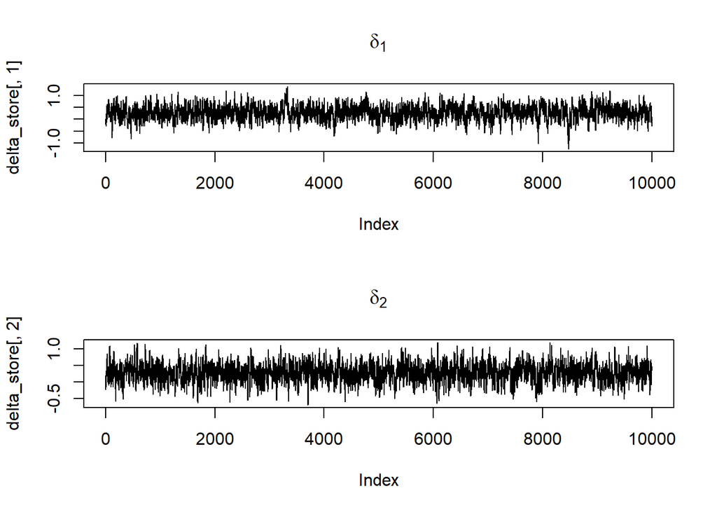

```r
par(mfrow = c(2,1))

plot(
  delta_store[,1],
  type="l",
  main=expression(delta[1])
)

plot(
  delta_store[,2],
  type="l",
  main=expression(delta[2])
)
```

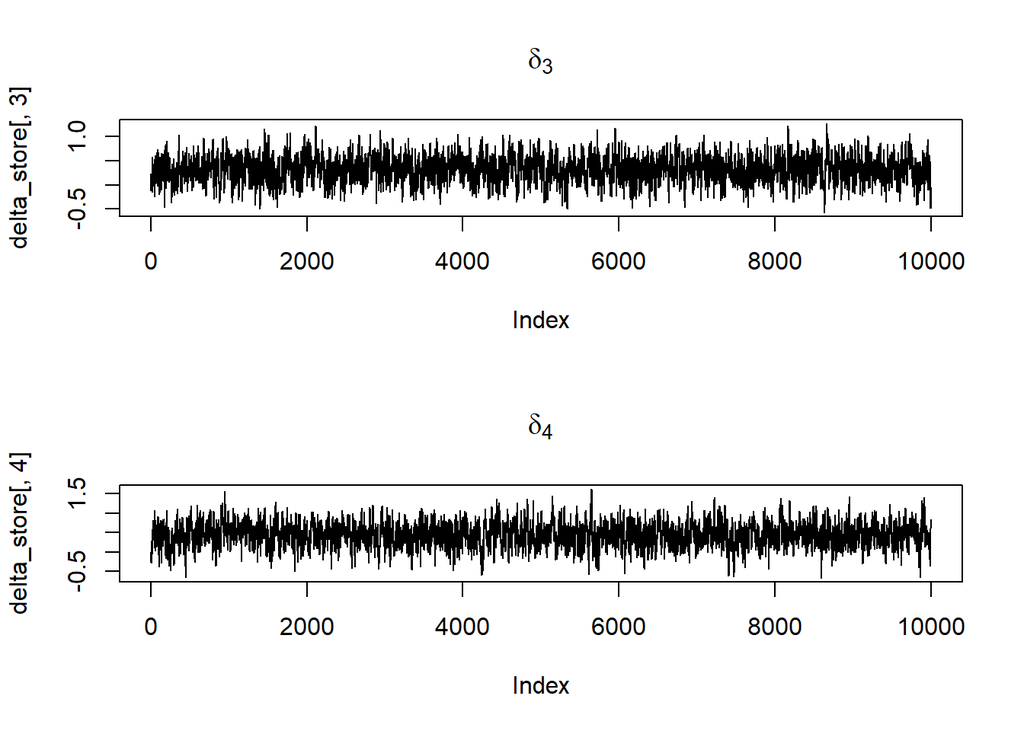

```r
plot(
  delta_store[,3],
  type="l",
  main=expression(delta[3])
)

plot(
  delta_store[,4],
  type="l",
  main=expression(delta[4])
)
```

Combined table

```r
combined_results <- data.frame(

  Item = 1:J_verbal,

  MH_p_value = round(mh_verbal$p.value, 4),

  MH_alpha = round(mh_verbal$alphaMH, 3),

  Posterior_Mean = round(delta_mean, 3),

  Lower95 = round(delta_ci[1,], 3),

  Upper95 = round(delta_ci[2,], 3)

)

combined_results$Bayesian_DIF <-
  ifelse(
    combined_results$Lower95 > 0 |
    combined_results$Upper95 < 0,
    "Yes",
    "No"
  )

combined_results$MH_DIF <-
  ifelse(
    combined_results$MH_p_value < .05,
    "Yes",
    "No"
  )

combined_results
```

```
##    Item MH_p_value MH_alpha Posterior_Mean Lower95 Upper95 Bayesian_DIF MH_DIF
## 1     1     0.1913    1.700          0.285  -0.365   0.872           No     No
## 2     2     0.1427    1.770          0.276  -0.275   0.815           No     No
## 3     3     0.3191    1.448          0.326  -0.221   0.851           No     No
## 4     4     0.1647    1.939          0.442  -0.197   1.077           No     No
## 5     5     0.0857    1.980          0.311  -0.272   0.909           No     No
## 6     6     0.0019    2.880          0.802   0.266   1.356          Yes    Yes
## 7     7     0.9711    0.944          0.066  -0.516   0.619           No     No
## 8     8     0.4112    0.719         -0.345  -0.895   0.212           No     No
## 9     9     0.3656    1.528          0.459  -0.195   1.107           No     No
## 10   10     0.2018    1.685          0.288  -0.322   0.906           No     No
## 11   11     0.9020    1.090         -0.081  -0.643   0.468           No     No
## 12   12     0.0424    2.346          0.560  -0.080   1.160           No    Yes
## 13   13     0.7160    0.797         -0.320  -0.988   0.282           No     No
## 14   14     0.0972    0.499         -0.577  -1.140   0.006           No     No
## 15   15     0.7938    1.177          0.200  -0.376   0.792           No     No
## 16   16     0.0121    0.321         -0.878  -1.515  -0.232          Yes    Yes
## 17   17     0.0089    0.375         -0.824  -1.392  -0.261          Yes    Yes
## 18   18     0.6414    0.793         -0.110  -0.700   0.504           No     No
## 19   19     0.0162    0.462         -0.720  -1.278  -0.163          Yes    Yes
## 20   20     0.0486    0.473         -0.571  -1.184   0.017           No    Yes
## 21   21     0.5846    0.637         -0.191  -0.935   0.586           No     No
## 22   22     0.2895    0.644         -0.445  -1.036   0.114           No     No
## 23   23     0.2287    0.639         -0.420  -0.974   0.150           No     No
## 24   24     0.3597    1.605          0.364  -0.299   1.083           No     No
```

```r
write.csv(
  combined_results,
  "../Data/processed/empirical_dif_comparison.csv",
  row.names = FALSE
)
```

extract the tables for overleaf

```r
library(xtable)

print(
  xtable(combined_results,
         caption = "Comparison of Mantel--Haenszel and Bayesian DIF results.",
         label = "tab:empirical"),
  include.rownames = FALSE
)
```

```
## % latex table generated in R 4.2.2 by xtable 1.8-4 package
## % Fri Sep 18 17:21:00 2026
## \begin{table}[ht]
## \centering
## \begin{tabular}{rrrrrrll}
##   \hline
## Item & MH\_p\_value & MH\_alpha & Posterior\_Mean & Lower95 & Upper95 & Bayesian\_DIF & MH\_DIF \\
##   \hline
##   1 & 0.19 & 1.70 & 0.28 & -0.36 & 0.87 & No & No \\
##     2 & 0.14 & 1.77 & 0.28 & -0.28 & 0.81 & No & No \\
##     3 & 0.32 & 1.45 & 0.33 & -0.22 & 0.85 & No & No \\
##     4 & 0.16 & 1.94 & 0.44 & -0.20 & 1.08 & No & No \\
##     5 & 0.09 & 1.98 & 0.31 & -0.27 & 0.91 & No & No \\
##     6 & 0.00 & 2.88 & 0.80 & 0.27 & 1.36 & Yes & Yes \\
##     7 & 0.97 & 0.94 & 0.07 & -0.52 & 0.62 & No & No \\
##     8 & 0.41 & 0.72 & -0.34 & -0.90 & 0.21 & No & No \\
##     9 & 0.37 & 1.53 & 0.46 & -0.20 & 1.11 & No & No \\
##    10 & 0.20 & 1.68 & 0.29 & -0.32 & 0.91 & No & No \\
##    11 & 0.90 & 1.09 & -0.08 & -0.64 & 0.47 & No & No \\
##    12 & 0.04 & 2.35 & 0.56 & -0.08 & 1.16 & No & Yes \\
##    13 & 0.72 & 0.80 & -0.32 & -0.99 & 0.28 & No & No \\
##    14 & 0.10 & 0.50 & -0.58 & -1.14 & 0.01 & No & No \\
##    15 & 0.79 & 1.18 & 0.20 & -0.38 & 0.79 & No & No \\
##    16 & 0.01 & 0.32 & -0.88 & -1.51 & -0.23 & Yes & Yes \\
##    17 & 0.01 & 0.38 & -0.82 & -1.39 & -0.26 & Yes & Yes \\
##    18 & 0.64 & 0.79 & -0.11 & -0.70 & 0.50 & No & No \\
##    19 & 0.02 & 0.46 & -0.72 & -1.28 & -0.16 & Yes & Yes \\
##    20 & 0.05 & 0.47 & -0.57 & -1.18 & 0.02 & No & Yes \\
##    21 & 0.58 & 0.64 & -0.19 & -0.94 & 0.59 & No & No \\
##    22 & 0.29 & 0.64 & -0.44 & -1.04 & 0.11 & No & No \\
##    23 & 0.23 & 0.64 & -0.42 & -0.97 & 0.15 & No & No \\
##    24 & 0.36 & 1.60 & 0.36 & -0.30 & 1.08 & No & No \\
##    \hline
## \end{tabular}
## \caption{Comparison of Mantel--Haenszel and Bayesian DIF results.}
## \label{tab:empirical}
## \end{table}
```

#### hypothesis testing

```r
library(bain)

library(restriktor)
```

```r
dat_goric <- data.frame(

d6  = delta_post[,6],

d16 = delta_post[,16],

d17 = delta_post[,17],

d19 = delta_post[,19]

)
```

```r
fit_goric <- lm(
cbind(d6,d16,d17,d19) ~ 1,
data = dat_goric
)
```

```r
dat <- data.frame(
  d6 = delta_post[,6],
  d16 = delta_post[,16],
  d17 = delta_post[,17],
  d19 = delta_post[,19]
)

fit <- lm(cbind(d6,d16,d17,d19) ~ 1, data = dat)
```

```r
d6 <- delta_post[,6]

d16 <- delta_post[, 16]

d17 <- delta_post[, 17]

d19 <- delta_post[, 19]
```

measurement invariance

```r
H1 <- mean(
  abs(d6)  < 0.10 &
  abs(d16) < 0.10 &
  abs(d17) < 0.10 &
  abs(d19) < 0.10
)

H1
```

```
## [1] 0
```

Expected directions

```r
H2 <- mean(
  d6  > 0 &
  d16 < 0 &
  d17 < 0 &
  d19 < 0
)

H2
```

```
## [1] 0.987375
```

Ordered effects

```r
H3 <- mean(
  d16 < d17 &
  d17 < d19 &
  d19 < 0 &
  d6 > 0
)

H3
```

```
## [1] 0.2595
```

Summarise the results

```r
hypothesis_results <- data.frame(

  Hypothesis = c(
    "Measurement invariance",
    "Directional DIF",
    "Ordered DIF effects"
  ),

  Posterior_Probability = round(
    c(H1, H2, H3),
    3
  )

)

hypothesis_results
```

```
##               Hypothesis Posterior_Probability
## 1 Measurement invariance                 0.000
## 2        Directional DIF                 0.987
## 3    Ordered DIF effects                 0.260
```

Fit log regression for each item

```r
fit6 <- glm(
  Y_verbal[,6] ~ theta_verbal + group_verbal,
  family = binomial
)

fit16 <- glm(
  Y_verbal[,16] ~ theta_verbal + group_verbal,
  family = binomial
)

fit17 <- glm(
  Y_verbal[,17] ~ theta_verbal + group_verbal,
  family = binomial
)

fit19 <- glm(
  Y_verbal[,19] ~ theta_verbal + group_verbal,
  family = binomial
)
```

```r
bain6 <- bain(
  fit6,
  "group_verbal = 0;
   group_verbal > 0;
   group_verbal < 0"
)

summary(bain6)
```

```
##      Parameter   n  Estimate       lb        ub
## 1 group_verbal 316 -1.090154 -1.74406 -0.436249
```

```r
bain6$fit
```

```
##         Fit_eq     Com_eq       Fit_in Com_in          Fit          Com
## H1 0.005743796 0.06726663 1.0000000000    1.0 5.743796e-03 6.726663e-02
## H2 1.000000000 1.00000000 0.0005424291    0.5 5.424291e-04 5.000000e-01
## H3 1.000000000 1.00000000 0.9994575709    0.5 9.994576e-01 5.000000e-01
## Hu          NA         NA           NA     NA           NA           NA
## Hc          NA         NA           NA     NA 5.417888e-14 4.363176e-14
##              BF         PMPa         PMPb        BF.u         BF.c PMPc
## H1 8.538850e-02 0.0409460860 0.0276751200 0.085388497 8.538850e-02   NA
## H2 5.427234e-04 0.0005202187 0.0003516115 0.001084858 5.427234e-04   NA
## H3 1.842559e+03 0.9585336953 0.6478649752 1.998915142 1.842559e+03   NA
## Hu           NA           NA 0.3241082933          NA           NA   NA
## Hc           NA           NA           NA          NA           NA   NA
```

```r
bain16 <- bain(
  fit16,
  "group_verbal = 0;
   group_verbal < 0;
   group_verbal > 0"
)

bain17 <- bain(
  fit17,
  "group_verbal = 0;
   group_verbal < 0;
   group_verbal > 0"
)

bain19 <- bain(
  fit19,
  "group_verbal = 0;
   group_verbal < 0;
   group_verbal > 0"
)



summary(bain16)
```

```
##      Parameter   n  Estimate        lb       ub
## 1 group_verbal 316 0.9836769 0.2574382 1.709916
```

```r
summary(bain17)
```

```
##      Parameter   n Estimate        lb       ub
## 1 group_verbal 316 1.032969 0.3481919 1.717746
```

```r
summary(bain19)
```

```
##      Parameter   n  Estimate        lb       ub
## 1 group_verbal 316 0.8222815 0.2119112 1.432652
```

full table

```r
hypothesis_results <- data.frame(

  Item = c(6,16,17,19),

  No_DIF = c(
    bain6$fit["H1","Fit_eq"],
    bain16$fit["H1","Fit_eq"],
    bain17$fit["H1","Fit_eq"],
    bain19$fit["H1","Fit_eq"]
  ),

  Expected_Direction = c(
    bain6$fit["H2","Fit_in"],
    bain16$fit["H2","Fit_in"],
    bain17$fit["H2","Fit_in"],
    bain19$fit["H2","Fit_in"]
  ),

  Opposite_Direction = c(
    bain6$fit["H3","Fit_in"],
    bain16$fit["H3","Fit_in"],
    bain17$fit["H3","Fit_in"],
    bain19$fit["H3","Fit_in"]
  )

)

round(hypothesis_results,3)
```

```
##   Item No_DIF Expected_Direction Opposite_Direction
## 1    6  0.006              0.001              0.999
## 2   16  0.032              0.004              0.996
## 3   17  0.014              0.002              0.998
## 4   19  0.039              0.004              0.996
```

```r
hypothesis_results <- data.frame(

  Item = c(6,16,17,19),

  No_DIF = c(
    bain6$fit["H1","Fit_eq"],
    bain16$fit["H1","Fit_eq"],
    bain17$fit["H1","Fit_eq"],
    bain19$fit["H1","Fit_eq"]
  ),

  Expected_DIF = c(
    bain6$fit["H2","Fit_in"],
    bain16$fit["H2","Fit_in"],
    bain17$fit["H2","Fit_in"],
    bain19$fit["H2","Fit_in"]
  ),

  Opposite_DIF = c(
    bain6$fit["H3","Fit_in"],
    bain16$fit["H3","Fit_in"],
    bain17$fit["H3","Fit_in"],
    bain19$fit["H3","Fit_in"]
  )

)

round(hypothesis_results,3)
```

```
##   Item No_DIF Expected_DIF Opposite_DIF
## 1    6  0.006        0.001        0.999
## 2   16  0.032        0.004        0.996
## 3   17  0.014        0.002        0.998
## 4   19  0.039        0.004        0.996
```

Using PMPb

```r
hypothesis_results <- data.frame(

Item = c(6,16,17,19),

No_DIF = c(
bain6$fit["H1","PMPb"],
bain16$fit["H1","PMPb"],
bain17$fit["H1","PMPb"],
bain19$fit["H1","PMPb"]
),

Expected_DIF = c(
bain6$fit["H2","PMPb"],
bain16$fit["H2","PMPb"],
bain17$fit["H2","PMPb"],
bain19$fit["H2","PMPb"]
),

Opposite_DIF = c(
bain6$fit["H3","PMPb"],
bain16$fit["H3","PMPb"],
bain17$fit["H3","PMPb"],
bain19$fit["H3","PMPb"]
)

)

round(hypothesis_results,3)
```

```
##   Item No_DIF Expected_DIF Opposite_DIF
## 1    6  0.028        0.000        0.648
## 2   16  0.149        0.002        0.565
## 3   17  0.070        0.001        0.619
## 4   19  0.154        0.002        0.562
```

```r
hypothesis_results <- data.frame(

Item = c(6,16,17,19),

No_DIF = c(
bain6$fit["H1","PMPb"],
bain16$fit["H1","PMPb"],
bain17$fit["H1","PMPb"],
bain19$fit["H1","PMPb"]
),

Expected_DIF = c(
bain6$fit["H2","PMPb"],
bain16$fit["H2","PMPb"],
bain17$fit["H2","PMPb"],
bain19$fit["H2","PMPb"]
),

Opposite_DIF = c(
bain6$fit["H3","PMPb"],
bain16$fit["H3","PMPb"],
bain17$fit["H3","PMPb"],
bain19$fit["H3","PMPb"]
),

Unconstrained = c(
bain6$fit["Hu","PMPb"],
bain16$fit["Hu","PMPb"],
bain17$fit["Hu","PMPb"],
bain19$fit["Hu","PMPb"]
)

)

round(hypothesis_results,3)
```

```
##   Item No_DIF Expected_DIF Opposite_DIF Unconstrained
## 1    6  0.028        0.000        0.648         0.324
## 2   16  0.149        0.002        0.565         0.284
## 3   17  0.070        0.001        0.619         0.310
## 4   19  0.154        0.002        0.562         0.282
```

Table for overleaf

```r
library(xtable)

print(
xtable(
hypothesis_results,
caption = "Posterior model probabilities obtained from Bayesian hypothesis testing.",
label = "tab:bain"
),
include.rownames = FALSE
)
```

```
## % latex table generated in R 4.2.2 by xtable 1.8-4 package
## % Fri Sep 18 17:21:56 2026
## \begin{table}[ht]
## \centering
## \begin{tabular}{rrrrr}
##   \hline
## Item & No\_DIF & Expected\_DIF & Opposite\_DIF & Unconstrained \\
##   \hline
## 6.00 & 0.03 & 0.00 & 0.65 & 0.32 \\
##   16.00 & 0.15 & 0.00 & 0.57 & 0.28 \\
##   17.00 & 0.07 & 0.00 & 0.62 & 0.31 \\
##   19.00 & 0.15 & 0.00 & 0.56 & 0.28 \\
##    \hline
## \end{tabular}
## \caption{Posterior model probabilities obtained from Bayesian hypothesis testing.}
## \label{tab:bain}
## \end{table}
```

GORIC

```r
beta <- c(
  delta_mean[6],
  delta_mean[16],
  delta_mean[17],
  delta_mean[19]
)

names(beta) <- c("d6","d16","d17","d19")

beta
```

```
##         d6        d16        d17        d19
##  0.8015398 -0.8777285 -0.8240939 -0.7202257
```

```r
Sigma <- cov(
  delta_post[, c(6,16,17,19)]
)

Sigma
```

```
##               [,1]          [,2]         [,3]         [,4]
## [1,]  0.0780476440  0.0005896491 -0.001111444  0.002649344
## [2,]  0.0005896491  0.1067029788 -0.002974171 -0.001750965
## [3,] -0.0011114440 -0.0029741711  0.081963847  0.001430389
## [4,]  0.0026493442 -0.0017509647  0.001430389  0.080476687
```

```r
H1 <- "d6 = d16 = d17 = d19 = 0"
H2 <- "
d6 > 0
d16 < 0
d17 < 0
d19 < 0
"
H3 <- "
d16 < d17
d17 < d19
d19 < 0
d6 > 0
"
H4 <- "
d16 < d17
d16 < d19
d6 > 0
"
```